# Modeling Mortality

Thomas Benacci

2025-12-31

# Introduction

This .Rmd replicates the methodology of *Predicting Mortality From 57 Economic, Behavioral, Social, and Psychological Factors* by Puterman et al. (2020), who used data from the U.S. Health and Retirement Study (HRS) to predict mortality from 57 (39 when using the Midlife in the United States (MIDUS) data set per the authors, 44 in our interpretation) behavioral, social, and psychological variables.

The MIDUS study surveyed a nationally representative sample of Americans aged 25 to 74 in 1995–96, then tracked mortality through 2019. In the 23 years between the survey and mortality status check, a subset of the original cohort died. We model the time-to-death using Cox proportional hazards regression, treating age as the time scale and death as the event of interest.

As an introduction to hazard modeling, I found Chapter 11: Survival Analysis and Censored Data of *Introduction to Statistical Learning* James et al. (2013) to be helpful, especially given it’s emphasis on health examples to explore concepts.

# Data

The feature dataset contains 44 standardized variables (prefixed `char_`) drawn from the MIDUS Wave 1 survey, plus the outcome variables `DECEASED` (1: deceased, 0: alive) and `Max_Age` (age at death or last known alive). Continuous predictors have been z-scored against the full MIDUS sample and binary predictors are coded as −1/1.

```r
data <- fread(
  "Survey_1_feature_data.csv",
  data.table = F
)
# All char_ variables are predictors — no demographic/non-demographic split
all_vars <- grep("^char_", names(data), value = TRUE)
cat("Number of predictors:", length(all_vars), "\n")
```

```
## Number of predictors: 44
```

```r
cat("Variables:", paste(all_vars, collapse = ", "), "\n")
```

```
## Variables: char_Age, char_LowFatherEdu, char_LowMotherEdu, char_LowerIncome, char_LowerWealth, char_LowerEdu, char_RecentFinDiff, char_LowNeighborCohesion, char_SleepProblems, char_LowerPosIntWithFamily, char_NegIntWithFamily, char_LowerPosIntWithFriends, char_NegIntWithFriends, char_LowerAgreeab…
```

# Kaplan-Meier Survival Curve

Before fitting any predictive models, we estimate the unconditional survival function using the Kaplan–Meier estimator. This gives us the baseline picture: what fraction of the MIDUS sample was still alive at each age? The curve declines gradually through middle age and steepens after 70, reflecting the familiar pattern of accelerating mortality risk in later life. The shaded confidence band widens at the extremes where fewer observations remain at risk.

This overall curve represents the average trajectory across all participants. The goal of the Cox models that follow is to explain variation around this average and identify which individuals face steeper or shallower curves based on their life circumstances and characteristics.

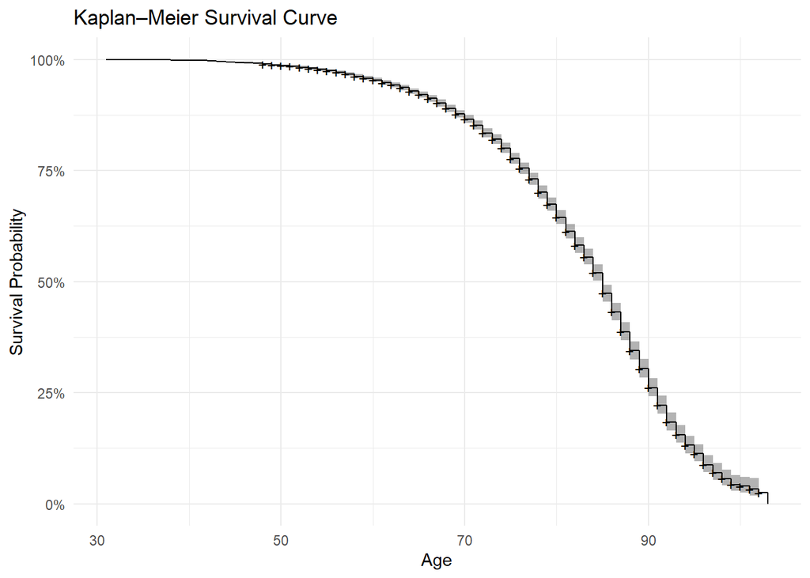

```r
km_fit <- survfit(Surv(Max_Age, DECEASED) ~ 1, data = data)

autoplot(km_fit) +
  labs(
    title = "Kaplan–Meier Survival Curve",
    x = "Age",
    y = "Survival Probability"
  ) +
  theme_minimal()
```

# Independent Cox Proportional Hazards Models (Replicating Puterman Fig. 1 / Table 1)

This section replicates the paper’s primary analysis. Each of the 44 predictors is tested in its own Cox model with age as the baseline hazard (via `Surv(Max_Age, DECEASED)`) and standard errors clustered by household (`M2FAMNUM`) to account for non-independence among family members.

$$\lambda(t|X_{i}) = \lambda_{0}(t) \cdot \exp(\beta_{1}X_{i})$$

The output $\exp(\beta_{1}X_{i})$ is a hazard ratio (HR) for each predictor. An HR above 1 means the variable is associated with higher mortality risk (up-scales baseline mortality); below 1, lower risk (down-scales baseline mortality) Because we are running 44 parallel tests, we apply a Bonferroni correction to the confidence intervals.

Variables are coded so that higher values generally indicate what are perceived as worse conditions (e.g., “Lower Income” means lower income is coded as a higher number). This means we expect most significant HRs to be greater than 1.

```r
n_predictors <- length(all_vars)
bonferroni_alpha <- 0.05 / n_predictors
z_bonf <- qnorm(1 - bonferroni_alpha / 2)
# Run independent Cox models - one per predictor, no adjustment covariates
independent_results <- lapply(all_vars, function(pred){
  fml <- as.formula(paste0(
    "Surv(Max_Age, DECEASED) ~ ", pred,
    " + cluster(M2FAMNUM)"
  ))
  fit <- tryCatch(
    coxph(fml, data = data),
    error = function(e) NULL
  )
  if (is.null(fit)) return(NULL)
  s <- summary(fit)
  coef_row <- s$coefficients[pred, , drop = FALSE]
  hr <- exp(coef_row[, "coef"])
  se <- coef_row[, "robust se"]
  log_hr <- coef_row[, "coef"]
  p_val <- coef_row[, "Pr(>|z|)"]
  # Standard 95% CI
  ci_lo_95 <- exp(log_hr - 1.96 * se)
  ci_hi_95 <- exp(log_hr + 1.96 * se)
  # Bonferroni-corrected CI
  ci_lo_bonf <- exp(log_hr - z_bonf * se)
  ci_hi_bonf <- exp(log_hr + z_bonf * se)

  data.frame(
    Variable = pred,
    HR = hr,
    CI_lo_95 = ci_lo_95,
    CI_hi_95 = ci_hi_95,
    CI_lo_bonf = ci_lo_bonf,
    CI_hi_bonf = ci_hi_bonf,
    p_value = p_val,
    p_bonf_sig = p_val < bonferroni_alpha,
    stringsAsFactors = FALSE
  )
})
# Combine and sort by HR descending
independent_df <- bind_rows(independent_results) %>%
  arrange(desc(HR))
# Clean up variable names for display
independent_df$Variable_clean <- independent_df$Variable %>%
  str_remove("^char_") %>%
  str_replace_all("([a-z])([A-Z])", "\\1 \\2") %>%
  str_replace_all("_", " ")
# Print ranked results
independent_df %>%
  select(Variable_clean, HR, CI_lo_95, CI_hi_95, CI_lo_bonf, CI_hi_bonf, p_value, p_bonf_sig)
```

```
##                   Variable_clean        HR  CI_lo_95  CI_hi_95 CI_lo_bonf
## 1                 Current Smoker 1.6455347 1.5632689 1.7321297  1.5112082
## 2                  Alcohol Abuse 1.4016826 1.2194055 1.6112065  1.1122253
## 3                Hist Of Smoking 1.3529953 1.2955795 1.4129557  1.2590042
## 4                  Never Married 1.2612885 1.1686427 1.3612789  1.1112220
## 5                Hist Of Renting 1.2322730 1.1625391 1.3061897  1.1186644
## 6                   Lower Wealth 1.2033234 1.1502561 1.2588389  1.1164999
## 7            Low No Mod Activity 1.1900359 1.1346177 1.2481609  1.0994418
## 8           Hist Of Unemployment 1.1890600 1.0577468 1.3366751  0.9790811
## 9                      Lower Edu 1.1870876 1.1392856 1.2368953  1.1087772
## 10       Lower Life Satisfaction 1.1798204 1.1348747 1.2265462  1.1061353
## 11               Neg Affectivity 1.1773680 1.1289984 1.2278099  1.0981496
## 12                  Lower Income 1.1724154 1.1142677 1.2335975  1.0774569
## 13                  Hopelessness 1.1697929 1.1217244 1.2199213  1.0910678
## 14               Recent Fin Diff 1.1682192 1.1165823 1.2222442  1.0837389
```

[output cut: 75 more lines]

# Forest Plot of Independent Cox Regression HRs (Fig. 1 Replication)

The forest plot below visualizes the HRs from the independent models, color-coded by the six life domains defined in Puterman et al.: Childhood Adversity, Adulthood Socioeconomic, Adulthood Health Behaviors, Adulthood Social Connections, Adulthood Psychological, and Adulthood Adverse Experiences (and Sociodemographic). Each point is a HR and horizontal bars show Bonferroni-corrected 95% confidence intervals (CI). Variables whose CIs do not cross 1 (the dashed vertical line) are statistically significant after correction for multiple testing.

Health behaviors, particularly current smoking and alcohol abuse, tend to produce the largest hazard ratios. Adult Socioeconomic variables have strong impacts on mortality as well. Many psychological variables show modest but consistent associations with mortality. The adverse experiences domain (daily and major discrimination) tends to produce weaker signals, which may reflect the difficulty of capturing these constructs with survey items.

```
## `height` was translated to `width`.
```

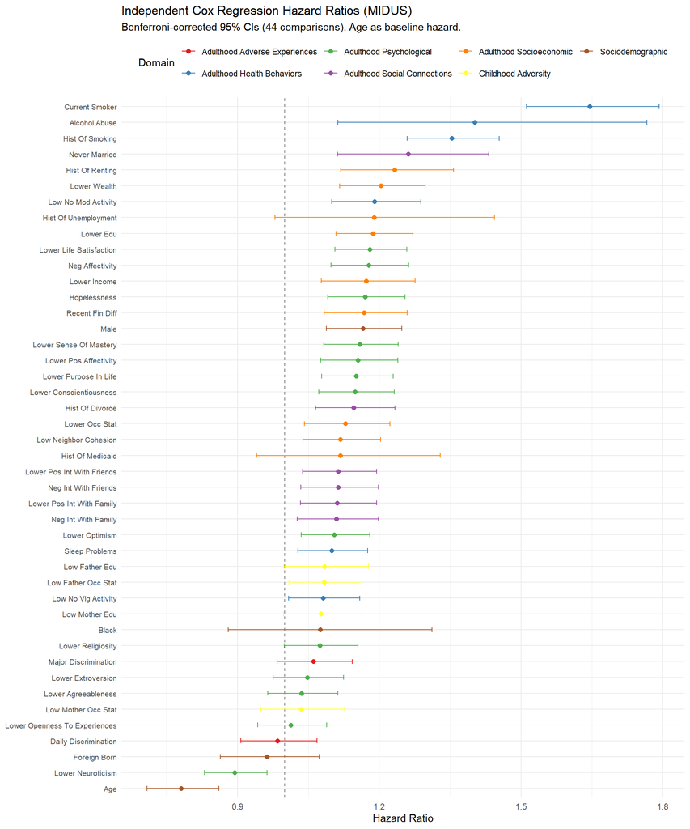

```r
# Assign domains for color coding (matching paper's 6 domains + demographics)
domain_map <- tribble(
  ~Variable,                       ~Domain,
  "char_Age",                      "Sociodemographic",
  "char_Male",                     "Sociodemographic",
  "char_Black",                    "Sociodemographic",
  "char_ForeignBorn",              "Sociodemographic",
  "char_LowFatherOccStat",         "Childhood Adversity",
  "char_LowMotherOccStat",         "Childhood Adversity",
  "char_LowFatherEdu",             "Childhood Adversity",
  "char_LowMotherEdu",             "Childhood Adversity",
  "char_LowerIncome",              "Adulthood Socioeconomic",
  "char_LowerWealth",              "Adulthood Socioeconomic",
  "char_LowerEdu",                 "Adulthood Socioeconomic",
  "char_LowerOccStat",             "Adulthood Socioeconomic",
  "char_RecentFinDiff",            "Adulthood Socioeconomic",
  "char_HistOfUnemployment",       "Adulthood Socioeconomic",
  "char_HistOfRenting",            "Adulthood Socioeconomic",
  "char_HistOfMedicaid",           "Adulthood Socioeconomic",
  "char_LowNeighborCohesion",      "Adulthood Socioeconomic",
  "char_AlcoholAbuse",             "Adulthood Health Behaviors",
  "char_CurrentSmoker",            "Adulthood Health Behaviors",
  "char_HistOfSmoking",            "Adulthood Health Behaviors",
  "char_LowNoModActivity",         "Adulthood Health Behaviors",
  "char_LowNoVigActivity",         "Adulthood Health Behaviors",
  "char_SleepProblems",            "Adulthood Health Behaviors",
  "char_HistOfDivorce",            "Adulthood Social Connections",
  "char_NeverMarried",             "Adulthood Social Connections",
  "char_LowerPosIntWithFamily",    "Adulthood Social Connections",
  "char_NegIntWithFamily",         "Adulthood Social Connections",
  "char_LowerPosIntWithFriends",   "Adulthood Social Connections",
  "char_NegIntWithFriends",        "Adulthood Social Connections",
  "char_LowerAgreeableness",       "Adulthood Psychological",
  "char_LowerExtroversion",        "Adulthood Psychological",
  "char_LowerNeuroticism",         "Adulthood Psychological",
  "char_LowerConscientiousness",   "Adulthood Psychological",
  "char_LowerOpennessToExperiences","Adulthood Psychological",
  "char_Hopelessness",             "Adulthood Psychological",
  "char_LowerLifeSatisfaction",    "Adulthood Psychological",
  "char_LowerOptimism",            "Adulthood Psychological",
  "char_LowerPosAffectivity",      "Adulthood Psychological",
  "char_NegAffectivity",           "Adulthood Psychological",
  "char_LowerPurposeInLife",       "Adulthood Psychological",
  "char_LowerReligiosity",         "Adulthood Psychological",
  "char_LowerSenseOfMastery",      "Adulthood Psychological",
  "char_DailyDiscrimination",      "Adulthood Adverse Experiences",
  "char_MajorDiscrimination",      "Adulthood Adverse Experiences"
)
#
plot_df <- independent_df %>%
  left_join(domain_map, by = "Variable") %>%
  mutate(
    Variable_clean = factor(Variable_clean, levels = rev(Variable_clean)) # ordered by HR
  )
#
ggplot(plot_df, aes(x = HR, y = Variable_clean, color = Domain)) +
  geom_vline(xintercept = 1, linetype = "dashed", color = "grey50") +
  geom_errorbarh(aes(xmin = CI_lo_bonf, xmax = CI_hi_bonf), height = 0.3) +
  geom_point(size = 2) +
  scale_color_brewer(palette = "Set1") +
  labs(
    title = "Independent Cox Regression Hazard Ratios (MIDUS)",
    subtitle = paste0("Bonferroni-corrected 95% CIs (", n_predictors, " comparisons). Age as baseline hazard."),
    x = "Hazard Ratio",
    y = NULL
  ) +
  theme_minimal() +
  theme(
    legend.position = "top",
    axis.text.y = element_text(size = 8)
  )
```

Confidence intervals in Puterman’s study and our rendition that do not include 1 are considered statistically significant at the 95% level.

- Coefficient signs of History of Medicaid are flipped (Puterman: <1, ~1, Us: >1), but both insignificant.
- Coefficient of Never Married is insignificant in Putnam, significant for us.
- Coefficient signs of Lower Openness to Experiences are flipped (Puterman: <1, Us: >1), but both insignificant.
- Coefficient signs of Lower Agreeableness are flipped (Puterman: <1, Us: >1), but both insignificant.
- Coefficient signs of Daily Discrimination are flipped (Puterman: >1, Us: <1), but both insignificant, though in Puterman just barely.
- Coefficient of Foreign Born significant in Putnam, insignificant for us, but both <1.

It is noteworthy that despite being seated between Current Smoker and History of Smoking coefficients, the confidence interval of Alcohol Abuse is the widest among the variable set, in Puterman’s results and our own. In fact, in Puterman’s study, the independent Cox regression coefficient is not statistically significant at 95% confidence.

# Variance Explained by Domain

How much does each domain of variables contribute to predicting mortality? We fit a separate Cox model for each domain and compute the generalized R-squared. This tells us how much of the variation in survival each domain can explain on its own. We also fit the full model with all 44 variables to see the combined explanatory power.

In-line with our observations above, Adulthood Health Behaviors are the most descriptive, followed by Adulthood Socioeconomic.

```r
# R-squared for each domain
domains_list <- split(domain_map$Variable, domain_map$Domain)
domain_r2 <- lapply(names(domains_list), function(d){
  vars_in_domain <- domains_list[[d]]
  # Ensure all vars exist in data
  vars_in_domain <- vars_in_domain[vars_in_domain %in% names(data)]
  fml <- as.formula(paste0(
    "Surv(Max_Age, DECEASED) ~ ",
    paste(vars_in_domain, collapse = " + ")
  ))
  fit <- coxph(fml, data = data)
  s <- summary(fit)
  data.frame(
    Domain = d,
    N_vars = length(vars_in_domain),
    R2_Royston = s$rsq[1],  # generalized R^2
    stringsAsFactors = FALSE
  )
})
domain_r2_df <- bind_rows(domain_r2) %>%
  arrange(desc(R2_Royston))
domain_r2_df
```

```
##                                Domain N_vars  R2_Royston
## rsq...1    Adulthood Health Behaviors      6 0.065873056
## rsq...2       Adulthood Socioeconomic      9 0.023680883
## rsq...3       Adulthood Psychological     13 0.019768650
## rsq...4  Adulthood Social Connections      6 0.017301519
## rsq...5              Sociodemographic      4 0.015771034
## rsq...6           Childhood Adversity      4 0.002867432
## rsq...7 Adulthood Adverse Experiences      2 0.001489135
```

```r
# All predictors combined
all_fml <- as.formula(paste0(
  "Surv(Max_Age, DECEASED) ~ ",
  paste(all_vars, collapse = " + ")
))
all_fit <- coxph(all_fml, data = data)
cat("\nAll", length(all_vars), "predictors combined R-squared:", round(summary(all_fit)$rsq[1], 4), "\n")
```

```
##
## All 44 predictors combined R-squared: 0.0998
```

# Lasso Cox Regression (Replicating Paper Fig. 2)

The independent models test each predictor in isolation, but many of these variables are correlated. Someone with low income also tends to have lower education, worse neighborhood quality, and more financial difficulty. When we enter all 44 variables simultaneously, some of this redundancy washes out. The lasso (L1-penalized) Cox regression handles this by shrinking weak or redundant coefficients toward zero and eliminating them entirely if they carry no unique information beyond what other variables already provide.

We use 10-fold cross-validation to select the penalty parameter (lambda) that minimizes the partial likelihood deviance. The resulting model retains only the variables that contribute independent predictive power. Variables that survive the lasso are those whose association with mortality cannot be explained away by other variables in the model.

Comparing the lasso results to the independent models is instructive. Some variables that looked strong in isolation (because they were proxies for a more fundamental predictor) may be eliminated by the lasso. Conversely, variables with modest individual hazard ratios may be retained if they capture unique variance.

```r
# Prepare model matrix (all predictors)
all_model_vars <- all_vars
# Remove rows with any NA in predictors OR response before building Surv object
complete_idx <- complete.cases(data[, c("Max_Age", "DECEASED", all_model_vars)])
data_complete <- data[complete_idx, ]
x_mat <- as.matrix(data_complete[, all_model_vars])
y_surv <- Surv(data_complete$Max_Age, data_complete$DECEASED)
cat("Complete cases for lasso:", nrow(data_complete), "of", nrow(data), "\n")
```

```
## Complete cases for lasso: 7105 of 7108
```

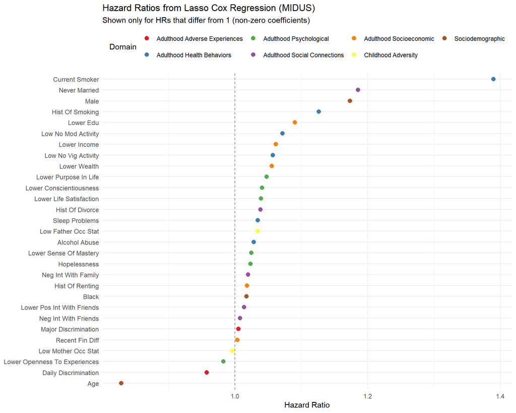

```r
# Cross-validated lasso
set.seed(42)
cv_fit <- cv.glmnet(x_mat, y_surv, family = "cox", alpha = 1, nfolds = 10)
# Extract coefficients at lambda.min
lasso_coefs <- coef(cv_fit, s = "lambda.min")
lasso_df <- data.frame(
  Variable = rownames(lasso_coefs),
  coef = as.numeric(lasso_coefs),
  HR = exp(as.numeric(lasso_coefs)),
  stringsAsFactors = FALSE
) %>%
  filter(coef != 0) %>%
  arrange(desc(HR))
# Clean names for display
lasso_df$Variable_clean <- lasso_df$Variable %>%
  str_remove("^char_") %>%
  str_replace_all("([a-z])([A-Z])", "\\1 \\2") %>%
  str_replace_all("_", " ")
lasso_df <- lasso_df %>%
  left_join(
    domain_map %>% mutate(Variable_clean = Variable %>%
      str_remove("^char_") %>%
      str_replace_all("([a-z])([A-Z])", "\\1 \\2") %>%
      str_replace_all("_", " ")),
    by = "Variable_clean"
  ) %>%
  # Mark demographic vars
  mutate(Domain = ifelse(is.na(Domain), "Sociodemographic", Domain))
# Plot
lasso_df %>%
  mutate(Variable_clean = factor(Variable_clean, levels = rev(Variable_clean))) %>%
  ggplot(aes(x = HR, y = Variable_clean, color = Domain)) +
  geom_vline(xintercept = 1, linetype = "dashed", color = "grey50") +
  geom_point(size = 2.5) +
  scale_color_brewer(palette = "Set1") +
  labs(
    title = "Hazard Ratios from Lasso Cox Regression (MIDUS)",
    subtitle = "Shown only for HRs that differ from 1 (non-zero coefficients)",
    x = "Hazard Ratio",
    y = NULL
  ) +
  theme_minimal() +
  theme(
    legend.position = "top",
    axis.text.y = element_text(size = 9)
  )
```

```r
# Print lasso results table
lasso_df %>%
  select(Variable_clean, HR, coef, Domain)
```

```
##                   Variable_clean        HR         coef
## 1                 Current Smoker 1.3895768  0.328999211
## 2                  Never Married 1.1856584  0.170298250
## 3                           Male 1.1732025  0.159737146
## 4                Hist Of Smoking 1.1262389  0.118883642
## 5                      Lower Edu 1.0902819  0.086436304
## 6            Low No Mod Activity 1.0716273  0.069178315
## 7                   Lower Income 1.0615898  0.059767584
## 8            Low No Vig Activity 1.0568813  0.055322438
## 9                   Lower Wealth 1.0553397  0.053862734
## 10         Lower Purpose In Life 1.0475503  0.046454346
## 11       Lower Conscientiousness 1.0408129  0.040002055
## 12       Lower Life Satisfaction 1.0392540  0.038503142
## 13               Hist Of Divorce 1.0385650  0.037839922
## 14                Sleep Problems 1.0342490  0.033675529
```

[output cut: 45 more lines]

Though HRS data was used to derive hazard ratios in Figure 2 of Puterman et al. (2020), our MIDUS rendition yields similar results, though notably Daily Discrimination is flipped. Out of the top 5 variables most indicative of mortality using time-to-event lasso regression in Puterman and our implementation of the study, Current Smoker, History of Smoking, and Male variables are shared in common, with Current Smoker being the leading indicator by far.

# Random Forest Survival Analysis (Replicating Paper SI Fig. S1)

The Cox models above assume a linear, additive, proportional-hazards relationship between predictors and mortality. The random survival forest relaxes all of these assumptions. It can capture nonlinearities (e.g., moderate drinking being protective but heavy drinking harmful), interactions (e.g., smoking being more dangerous for people with low physical activity), and non-proportional effects.

We fit 500 trees with permutation-based variable importance. A variable’s importance score reflects how much prediction accuracy degrades when that variable’s values are randomly shuffled across observations. Positive scores indicate genuine predictive value; scores near zero or negative suggest noise.

```r
# Prepare data for ranger (no NAs allowed)
rf_data <- data %>%
  select(Max_Age, DECEASED, all_of(all_model_vars)) %>%
  drop_na()
# Fit random survival forest
set.seed(42)
rf_fit <- ranger(
  Surv(Max_Age, DECEASED) ~ .,
  data = rf_data,
  num.trees = 500,
  importance = "permutation",
  mtry = floor(sqrt(length(all_model_vars))),
  min.node.size = 20
)
```

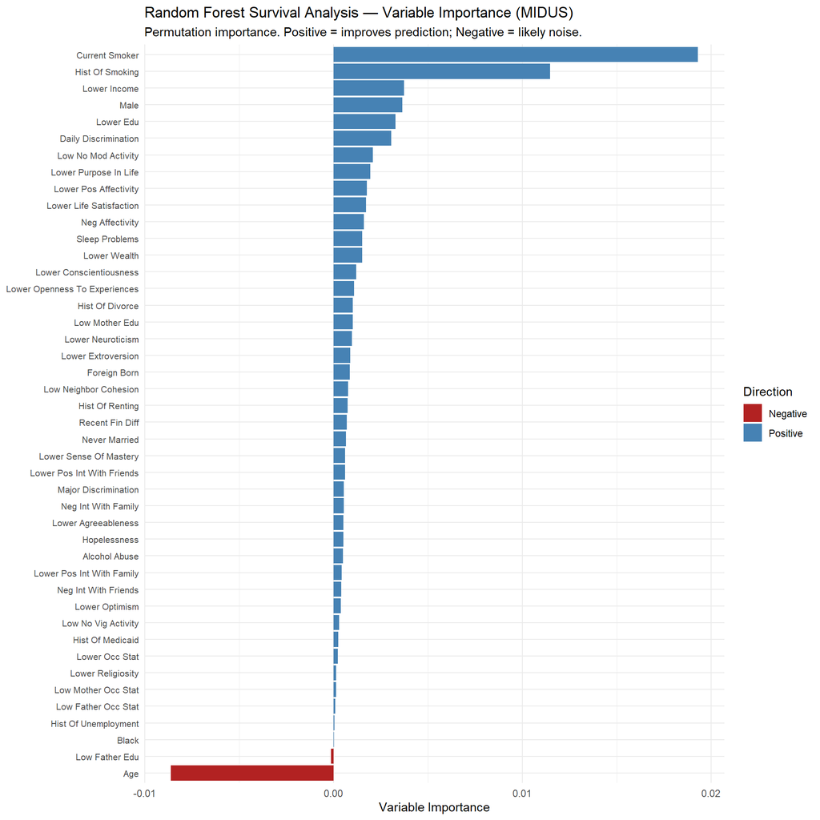

```r
# Variable importance
vimp <- data.frame(
  Variable = names(rf_fit$variable.importance),
  Importance = rf_fit$variable.importance,
  stringsAsFactors = FALSE
) %>%
  arrange(desc(Importance))
#
vimp$Variable_clean <- vimp$Variable %>%
  str_remove("^char_") %>%
  str_replace_all("([a-z])([A-Z])", "\\1 \\2") %>%
  str_replace_all("_", " ")
#
vimp <- vimp %>%
  left_join(
    domain_map %>% mutate(Variable_clean = Variable %>%
      str_remove("^char_") %>%
      str_replace_all("([a-z])([A-Z])", "\\1 \\2") %>%
      str_replace_all("_", " ")),
    by = "Variable_clean"
  ) %>%
  mutate(Domain = ifelse(is.na(Domain), "Sociodemographic", Domain))
#
vimp %>%
  mutate(Variable_clean = factor(Variable_clean, levels = rev(Variable_clean))) %>%
  ggplot(aes(x = Importance, y = Variable_clean, fill = ifelse(Importance > 0, "Positive", "Negative"))) +
  geom_col() +
  scale_fill_manual(values = c("Positive" = "steelblue", "Negative" = "firebrick"), name = "Direction") +
  labs(
    title = "Random Forest Survival Analysis — Variable Importance (MIDUS)",
    subtitle = "Permutation importance. Positive = improves prediction; Negative = likely noise.",
    x = "Variable Importance",
    y = NULL
  ) +
  theme_minimal() +
  theme(axis.text.y = element_text(size = 8))
```

# Save Model

We save the fitted Cox model object and the variable name lists so that downstream files. The personal mortality questionnaire (`my_mortality_prediction.Rmd`) and the portfolio Monte Carlo simulation (`portfolio_mc_simulation.Rmd`) can load the model without re-running this entire analysis.

```r
cox_full <- coxph(
  as.formula(paste0("Surv(Max_Age, DECEASED) ~ ", paste(all_vars, collapse = " + "))),
  data = data,
  model = TRUE,
  x = TRUE
)
saveRDS(cox_full, "cox_mortality_model.rds")
saveRDS(list(all_vars = all_vars), "model_variable_names.rds")
cat("Model and variable names saved.\n")
```

```
## Model and variable names saved.
```

```r
cat("Variables in model:", length(all_vars), "\n")
```

```
## Variables in model: 44
```